# Análisis de los Indicadores globales del mercado laboral en Bolivia, 2023

David Ayala

2025-02-11

# 1 Introducción

En este documento se analizan algunas variables del mercado laboral en Bolivia; para este propósito se empleó información de la encuesta continua de empleo del Instituto Nacional de Estadística del Estado Plurinacional de Bolivia [(INE, 2023)](https://anda.ine.gob.bo/index.php/catalog/ENCUESTAS).

```r
#Instalar y habilitar librerías
#install.packages(c("pacman","haven","ggplot2","magrittr","tidyverse","dplyr","sf","tisyr",
#                   "stringr","car","broom","sjlabelled","readr","epikit","ggrepel"))

pacman::p_load(
  haven,#Importar datos sav, dta, etc
  ggplot2,#Visualización de Datos
  magrittr,#pip
  tidyverse,
  dplyr,
  sf,#Para mapas
  tidyr,
  stringr,
  car,
  broom,
  sjlabelled,#Manejo de etiquetas dta, sav.
  readr,
  gghighlight,#Resaltar una categoría en específico en el plot.
  ggsankey,
  flextable, #tabla
  janitor,#Tablas
  epikit,#Para categorías numéricas
  ggrepel)#Etiquetas geom_text_grepel

#Theme
them_plot1 <- function(){
  theme_bw() +
    theme(legend.position = 'top',
          legend.justification = "left",
          legend.location = "plot",
          plot.title = element_text(color="#998ec3", face="bold", size=18),
          plot.title.position = "plot",
          plot.subtitle = element_text(color="gray12"),
          axis.text.x = element_text(face="bold", color="gray12",size=12),
          axis.text.y = element_blank(),
          axis.ticks.length.y = margin(0),
          axis.title = element_blank(),
          legend.title =element_blank(),
          legend.text =element_text(size=14),
          panel.grid.major = element_blank(),
          panel.grid.minor = element_blank())
}
##Colores son 11 categorias
new_colors <- c("#f1a340","#998ec3","#8DD3C7", "#FFFFB3","#FB8072", "#80B1D3", "#B3DE69", "#FCCDE5","#D9D9D9","#BC80BD","#CCEBC5")
```

## 1.1 Importar las Base de Datos

```r
#Cargar datos
setwd("~/Git_Portafolio/Portafolio/Inidcadores Laborales/Datos")
EE_1T <- read_sav("ECE_1T2023.sav")
EE_2T <- read_sav("ECE_2T2023.sav")
EE_3T <- read_sav("ECE_3T2023.sav")
EE_4T <- read_sav("ECE_4T2023.sav")

#Detalles de la muestra
list(EE_1T=dim(EE_1T),
     EE_2T=dim(EE_2T),
     EE_3T=dim(EE_3T),
     EE_4T=dim(EE_4T))
```

```
## $EE_1T
## [1] 52001   127
##
## $EE_2T
## [1] 52029   127
##
## $EE_3T
## [1] 51713   127
##
## $EE_4T
## [1] 51408   127
```

### 1.1.1 Anexar las Muestras

```r
#Anexar las base de datos (ECE)
ECE_23 <- EE_1T%>%
  bind_rows(.,EE_2T)%>%
  bind_rows(.,EE_3T)%>%
  bind_rows(.,EE_4T)

ECE_23 <- ECE_23 %>%
  rename(Sexo=s1_02,
         Edad=s1_03a,
         Rel_Par=s1_05)

dim(ECE_23)
```

```
## [1] 207151    127
```

### 1.1.2 Porcentaje de Observaciones por Trimestre

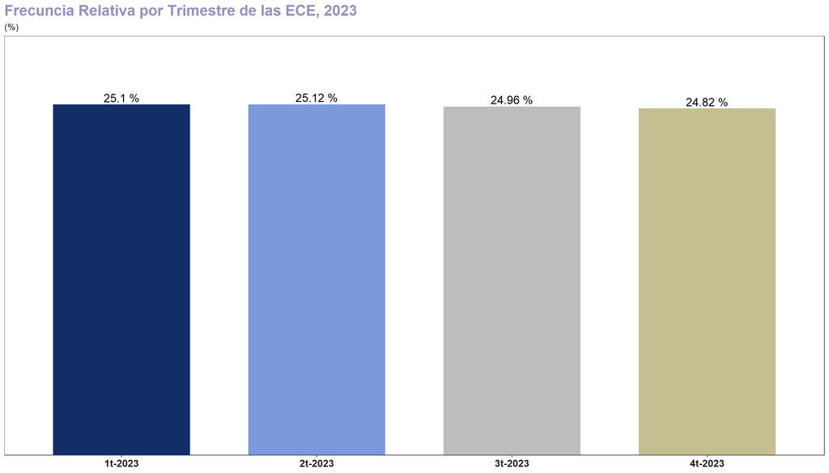

```r
#Detalles de la muestra (Frecuencia relativa)
ECE_23 %>%
  mutate(trim=as_label(trim)) %>%
  tabyl(trim) %>%
  filter(str_detect(trim, "2023")) %>%
  ggplot(aes(x=trim, y=percent, fill=trim))+
  geom_bar( stat = "identity",position = "identity", width=0.7,just = 0.5, show.legend = F)+
  theme_classic()+
  scale_y_continuous(expand = c(0,0,0,0),limits = c(0,0.3))+
  geom_text(aes(label=paste(round(percent*100,2),"%")), vjust=-0.3, size=14, size.unit = "pt")+
  scale_fill_manual(values = c("#122e68","#7a9add", "#BDBDBD","#c4be91"))+
  labs(title="Frecuncia Relativa por Trimestre de las ECE, 2023", subtitle = "(%)")+
  them_plot1()
```

# 2 Variables Laborales

Antes de continuar, es necesario definir los indicadores laborales estudiados.

1. **Población en Edad de Trabajar (PET)**: Población comprendida según el (INE, 2023), por personas mayores de 14 años de edad.
2. **La Población Economicamente Activa(PEA)**: Se conforma por la población ocupada y desocupada.
3. **La poblacion Ocupada(PO)**: Corresponde al conjunto de personas de 14 años o más de edad que trabajan en una actividad económica (sea o no remunerado).
4. **La Población Desocupada (PD)**: Son las personas de 14 años o más que, en la semana de referencia: no estaban ocupadas, llevaron a cabo actividades de búsqueda de trabajo en las últimas cuatro (4) semanas y estaban disponibles para trabajar.
5. **Tasa Global de Participación (TGP)**: Relación de la Población Económicamente Activa (PEA) entre la Población en Edad de Trabajar (PET) que mide la proporción de participación en el mercado laboral respecto al total de población que se encuentra en edad de trabajo.

```r
ECE_23 %>%
  filter(!is.na(condact)) %>%
  mutate(trim=as_label(trim),
         condact=as_label(condact)) %>%
  group_by(trim,condact) %>%
  tally() %>%
  pivot_wider(names_from = condact, values_from = n) %>%
  rename(PO=Ocupado) %>%
  mutate(
    PD=round(sum(Cesante,Aspirante),2),
    PET=round(sum(PO,PD,Temporal,Permanente),2),
    PEA=round(sum(PO,PD),2),
    "TGP (%)"=round(PEA/PET*100,2),
    "TD (%)"=round(PD/PEA*100,2),
    "TO (%)"=round(PO/PEA*100,2)
    ) %>%
  select(trim,PET,PEA, everything()) %>%
  select(-c(Cesante:Permanente)) %>%
  pivot_longer(PET:`TO (%)`, names_to = "Categoría",values_to = "n") %>%
  pivot_wider(names_from = trim, values_from = n) %>%
  qflextable()
```

| Categoría | 1t-2023 | 2t-2023 | 3t-2023 | 4t-2023 |
| --- | --- | --- | --- | --- |
| PET | 37,109.00 | 37,120.00 | 37,065.00 | 36,994.00 |
| PEA | 28,078.00 | 28,080.00 | 28,313.00 | 28,391.00 |
| PO | 26,907.00 | 27,135.00 | 27,407.00 | 27,482.00 |
| PD | 1,171.00 | 945.00 | 906.00 | 909.00 |
| TGP (%) | 75.66 | 75.65 | 76.39 | 76.74 |
| TD (%) | 4.17 | 3.37 | 3.20 | 3.20 |
| TO (%) | 95.83 | 96.63 | 96.80 | 96.80 |

## 2.1 Población por Condición de Actividad y Edad

```r
ECE_23%>%
  mutate(
    condact=as_label(condact),
    edad_cat=age_categories(Edad,
                            breakers=c(0,14,20,30,40,50,60,70)))%>%
  tabyl(condact, edad_cat)%>%
  adorn_totals(where =c("row","col")) %>%
  qflextable()
```

| condact | 0-13 | 14-19 | 20-29 | 30-39 | 40-49 | 50-59 | 60-69 | 70+ | Total |
| --- | --- | --- | --- | --- | --- | --- | --- | --- | --- |
| Ocupado | 0 | 9,601 | 24,095 | 24,952 | 21,060 | 15,169 | 9,564 | 4,490 | 108,931 |
| Cesante | 0 | 321 | 1,511 | 897 | 548 | 308 | 124 | 15 | 3,724 |
| Aspirante | 0 | 58 | 128 | 15 | 3 | 2 | 1 | 0 | 207 |
| Temporal | 0 | 4,896 | 5,965 | 2,935 | 1,797 | 1,860 | 3,283 | 4,992 | 25,728 |
| Permanente | 0 | 7,363 | 1,677 | 227 | 151 | 84 | 73 | 123 | 9,698 |
|  | 58,863 | 0 | 0 | 0 | 0 | 0 | 0 | 0 | 58,863 |
| Total | 58,863 | 22,239 | 33,376 | 29,026 | 23,559 | 17,423 | 13,045 | 9,620 | 207,151 |

# 3 Indicadores laborales por categorías

## 3.1 Tasa Global de Participación por Sexo

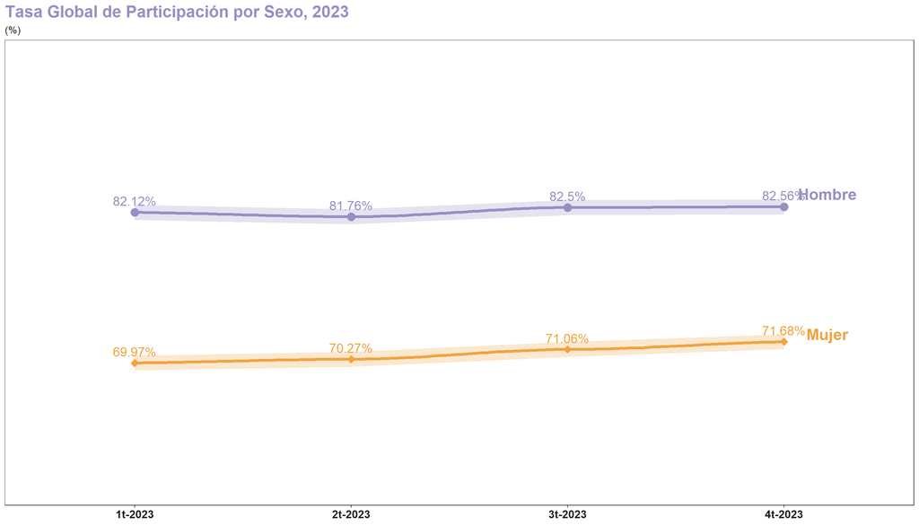

```r
ECE_23%>%
  filter(!is.na(condact)) %>%
  mutate(trim=as_label(trim),
         condact=as_label(condact),
         Sexo=as_label(Sexo)) %>%
  group_by(trim, Sexo, condact) %>%
  tally() %>%
  pivot_wider(names_from = condact, values_from = n) %>%
  mutate(Desocupado=Cesante+Aspirante,
         PEA=Ocupado+Desocupado) %>%
  select(-c(Cesante, Aspirante,Ocupado,Desocupado)) %>%
  adorn_totals(where = "col")%>%
  adorn_percentages()%>%
  mutate(yinf=PEA-0.006,
         ysup=PEA+0.006) %>%
  ggplot(aes(x=trim,y=PEA*100, group=Sexo, color=Sexo))+
  geom_ribbon(aes(ymin=yinf*100, ymax=ysup*100,fill=Sexo), alpha=0.25,colour=NA, show.legend = F)+
  geom_point(size=4, aes(shape=Sexo),show.legend = F)+
  geom_smooth(size=1.5, se=FALSE, show.legend = F)+
  scale_y_continuous(limits = c(60,90),expand = c(.05, 0, .2, 0))+
  annotate(geom = "text",x=4.2,y=c(72.3,83.6), label=c("Mujer","Hombre"), fontface="bold",color=c("#f1a340","#998ec3"), size=6)+
  labs(title = "Tasa Global de Participación por Sexo, 2023", subtitle = "(%)")+
  geom_text(aes(label=paste0(round(PEA*100, 2),"%")),   vjust=-0.7, size=14, size.unit = "pt", show.legend = F)+
  coord_cartesian(expand = 0.003)+
  scale_shape_manual(values=c(16,18))+
  scale_color_manual(labels = c("Hombre","Mujer"),values = c("#998ec3","#f1a340"))+
  scale_fill_manual(values = c("#998ec3","#f1a340"))+
  them_plot1()
```

## 3.2 Tasa Global de Participación por Sexo, Según Nivel Educativo Alcanzado

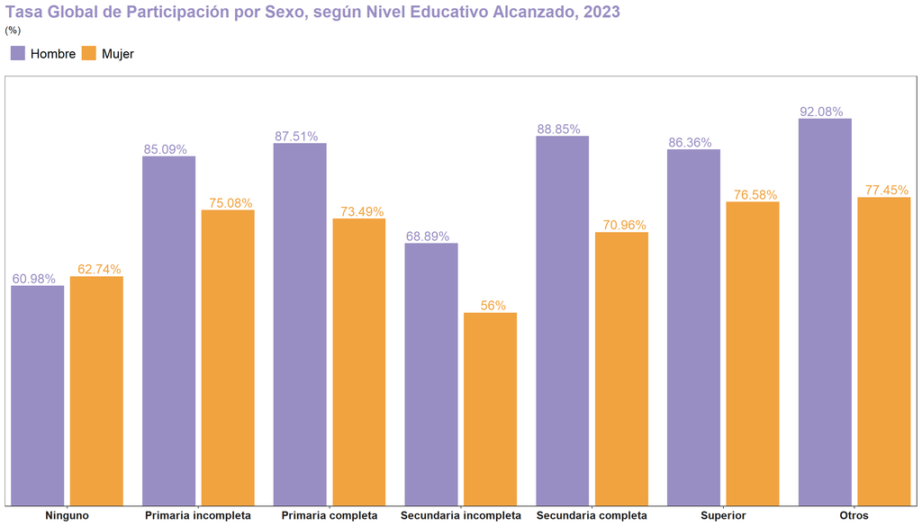

```r
ECE_23%>%
  filter(!is.na(condact)) %>%
  mutate(niv_ed=as_label(niv_ed),
         Sexo=as_label(Sexo),
         condact=as_label(condact))%>%
  group_by(niv_ed, Sexo, condact) %>%
  tally()%>%
  pivot_wider(names_from =condact, values_from = n) %>%
  mutate(PEA=sum(c(Ocupado, Cesante, Aspirante), na.rm = T)) %>% #Suma por columnas
  select(-c(Ocupado, Cesante, Aspirante))%>%
  adorn_totals(where = "col") %>%
  adorn_percentages(denominator = "row") %>%
  ggplot(aes(x=niv_ed,y=PEA*100, fill=Sexo))+
  geom_bar(position=position_dodge2(width = 1, preserve = "single"),stat = "identity", just = .5)+
  coord_cartesian(expand=FALSE,ylim = c(20,100))+
  geom_text(aes(label=paste0(round(PEA*100, 2),"%"),colour=Sexo), vjust=-0.3, hjust="center",   size=14, size.unit = "pt", position = position_dodge2(width = 1, preserve = "single"), show.legend = F)+#Etiquetas
  scale_fill_manual(values = c("#998ec3","#f1a340"), labels=c("Hombre", "Mujer"))+
  scale_colour_manual(values = c("#998ec3","#f1a340"))+#Color de las Etiquetas
  labs(title ="Tasa Global de Participación por Sexo, según Nivel Educativo Alcanzado, 2023", subtitle = "(%)" )+
  them_plot1()
```

## 3.3 Tasa de Global de Participación por Sexo, Según Rangos De Edad

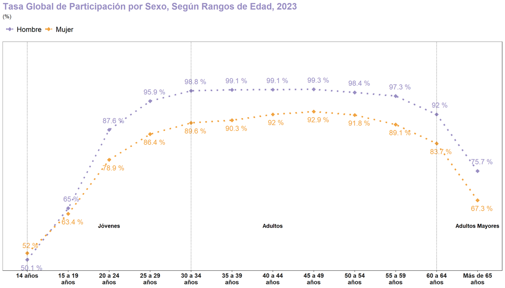

```r
ECE_23 %>%
  filter(!is.na(condact)) %>%
  mutate(condact=as_label(condact),
         Sexo=as_label(Sexo),
         Edad_Cat=case_when(
           Edad==14~"14 años",
           Edad>14 & Edad<=19~"15 a 19\naños",
           Edad>19 & Edad<=24~"20 a 24\naños",
           Edad>24 & Edad<=29~"25 a 29\naños",
           Edad>29 & Edad<=34~"30 a 34\naños",
           Edad>34 & Edad<=39~"35 a 39\naños",
           Edad>39 & Edad<=44~"40 a 44\naños",
           Edad>44 & Edad<=49~"45 a 49\naños",
           Edad>49 & Edad<=54~"50 a 54\naños",
           Edad>54 & Edad<=59~"55 a 59\naños",
           Edad>59 & Edad<=64~"60 a 64\naños",
           TRUE~"Más de 65\naños"
         ),
         Edad_Cat = factor(
           Edad_Cat,
           level = c("14 años", "15 a 19\naños","20 a 24\naños", "25 a 29\naños",
                     "30 a 34\naños","35 a 39\naños","40 a 44\naños","45 a 49\naños",
                     "50 a 54\naños","55 a 59\naños","60 a 64\naños","Más de 65\naños")
         )) %>%
  group_by(condact, Edad_Cat, Sexo)%>%
  tally() %>%
  pivot_wider(names_from = condact,values_from = n) %>%
  mutate(PEA=sum(c(Ocupado, Cesante, Aspirante), na.rm = T)) %>%
  select(-c(Ocupado, Cesante, Aspirante)) %>%
  adorn_totals(where = "col") %>%
  adorn_percentages(denominator = "row") %>%
  as_data_frame()  %>%
  ggplot(aes(x=Edad_Cat,y=PEA*100,group=Sexo, color=Sexo))+
  geom_point(shape=18, size=3.5)+
  geom_path(size=1.5,linetype="dotted",stat = "identity")+
  scale_color_manual(values = c("#998ec3","#f1a340"), label=c("Hombre","Mujer"))+
  labs(title = "Tasa Global de Participación por Sexo, Según Rangos de Edad, 2023",subtitle = "(%)")+
  coord_cartesian(ylim = c(50,110))+
  #Etiquetas por Grupo
  geom_text(aes(label=if_else(Sexo=="1. Hombre" & Edad_Cat!="14 años",paste(round(PEA*100, 1),"%"),NA), vjust=-1.3, hjust=0.3),size=14, size.unit = "pt", show.legend = F)+#Las etiq
  geom_text(aes(label=if_else(Sexo=="2. Mujer" & Edad_Cat!="14 años",paste(round(PEA*100, 1),"%"),NA),  vjust = 2, hjust=0.3),size=14, size.unit = "pt", show.legend = F)+
  geom_text(aes(label=if_else(Sexo=="1. Hombre"& Edad_Cat=="14 años",paste(round(PEA*100, 1),"%"),NA),  vjust =2, hjust=0.3),size=14, size.unit = "pt", show.legend = F)+
  geom_text(aes(label=if_else(Sexo=="2. Mujer"& Edad_Cat=="14 años",paste(round(PEA*100, 1),"%"),NA),  vjust =-1, hjust=0.3), size=14, size.unit = "pt",show.legend = F)+
  theme(legend.position='top', #Ubicación de legenda
        legend.justification='left',
        legend.direction='horizontal',
        legend.title=element_blank())+
  geom_vline(xintercept = c(1,5,11), linetype="dotted")+
  annotate(geom="text", x=c(3,7,12), y=60, label=c("Jóvenes","Adultos", "Adultos Mayores"),
           color="black", fontface="bold")+
  them_plot1()
```

# 4 Tasa de Ocupación y Desocupación

## 4.1 Tasa de Ocupación por Sexo

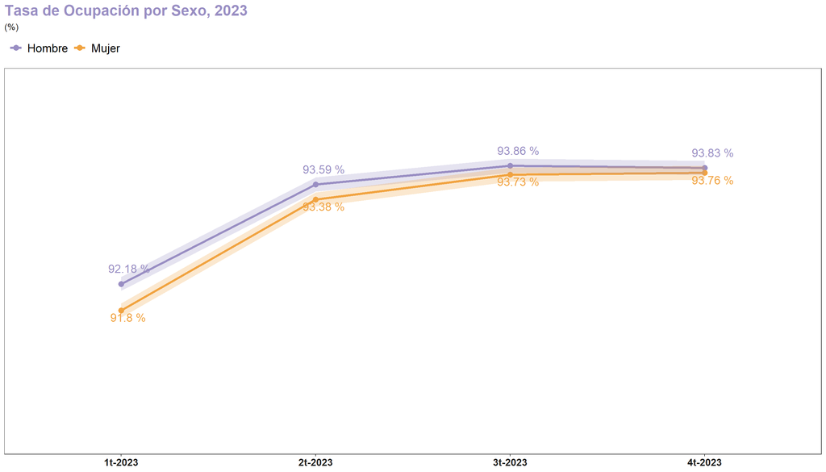

```r
ECE_23%>%
  filter(!is.na(condact)) %>%
  mutate(trim=as_label(trim),
         condact=as_label(condact),
         Sexo=as_label(Sexo)) %>%
  group_by(condact, trim, Sexo)%>%
  tally()%>%
  pivot_wider(names_from = condact, values_from = n)%>%
  mutate(Desocupado=sum(c(Cesante,Aspirante), na.rm = T)) %>%
  select(-c(Temporal,Permanente,Cesante,Aspirante))%>%
  adorn_totals(where = "col")%>%
  adorn_percentages(denominator = "row")%>%
  mutate(ysup=Ocupado+0.001,
         yinf=Ocupado-0.001) %>%
  ggplot(aes(x=trim,y=Ocupado, group=Sexo, color=Sexo))+
  geom_point(size=3)+
  geom_path(size=1.3)+
  geom_ribbon(aes(ymax=ysup, ymin=yinf, fill=Sexo), alpha=0.25, colour=NA, show.legend = F)+
  scale_y_continuous(limits = c(0.9,.95), n.breaks = 5, labels = scales::percent)+
  labs(x=NULL,y=NULL, title = "Tasa de Ocupación por Sexo, 2023",subtitle = "(%)")+
   geom_text(aes(label=if_else(Sexo=="1. Hombre",paste(round(Ocupado*100, 2),"%"),NA), vjust=-1.3, hjust=0.3),size=14, size.unit = "pt", show.legend = F)+
   geom_text(aes(label=if_else(Sexo=="2. Mujer" ,paste(round(Ocupado*100, 2),"%"),NA), vjust=1.3, hjust=0.3),size=14, size.unit = "pt", show.legend = F)+
  scale_color_manual(values = c("#998ec3","#f1a340"),label=c("Hombre","Mujer"))+
  scale_fill_manual(values=c("#998ec3","#f1a340"))+
  them_plot1()
```

## 4.2 Tasa de Desocupación por Sexo

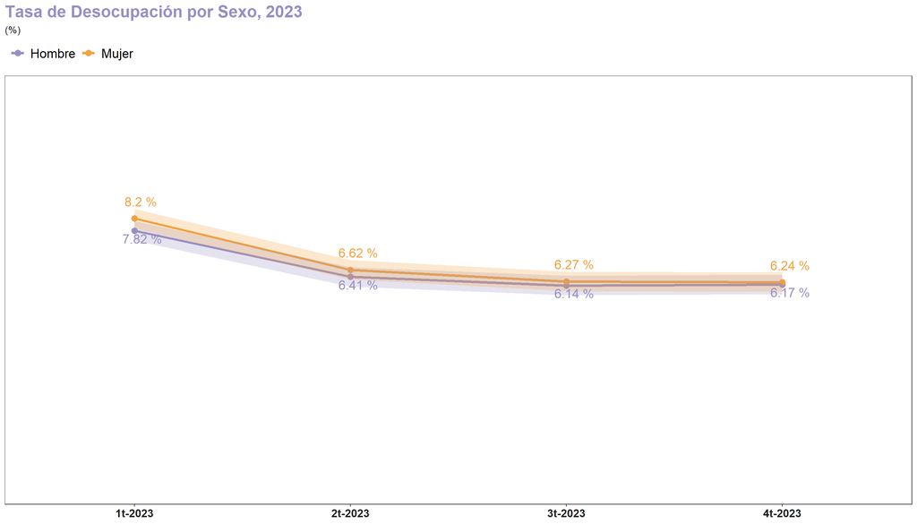

```r
#Población Desocupada
ECE_23%>%
  filter(!is.na(condact)) %>%
  mutate(trim=as_label(trim),
         condact=as_label(condact),
         Sexo=as_label(Sexo)) %>%
  group_by(condact, trim, Sexo)%>%
  tally()%>%#Factor de Expansión
  pivot_wider(names_from = condact, values_from = n)%>%
  mutate(Desocupado=sum(c(Cesante,Aspirante), na.rm = T)) %>%
  select(-c(Temporal,Permanente,Cesante,Aspirante))%>%
  adorn_totals(where = "col")%>%
  adorn_percentages(denominator = "row")%>%
  mutate(ysup=Desocupado+0.003,
         yinf=Desocupado-0.003) %>%
  ggplot(aes(x=trim,y=Desocupado, group=Sexo, color=Sexo))+
  geom_point(size=3)+
  geom_path(size=1.3)+
  geom_ribbon(aes(ymax=ysup, ymin=yinf, fill=Sexo), alpha=0.25, colour=NA, show.legend = F)+
  scale_y_continuous(limits = c(0,0.12),labels = scales::percent)+
  labs(x=NULL,y=NULL, title = "Tasa de Desocupación por Sexo, 2023",subtitle = "(%)")+
  geom_text(aes(label=if_else(Sexo=="1. Hombre",paste(round(Desocupado*100, 2),"%"),NA), vjust=1.3, hjust=0.3),size=14, size.unit = "pt", show.legend = F)+
   geom_text(aes(label=if_else(Sexo=="2. Mujer" ,paste(round(Desocupado*100, 2),"%"),NA), vjust=-1.3, hjust=0.3),size=14, size.unit = "pt", show.legend = F)+
  scale_color_manual(values = c("#998ec3","#f1a340"),label=c("Hombre","Mujer"))+
  scale_fill_manual(values=c("#998ec3","#f1a340"))+
  them_plot1()
```

## 4.3 Tasa de Ocupación por Departementos

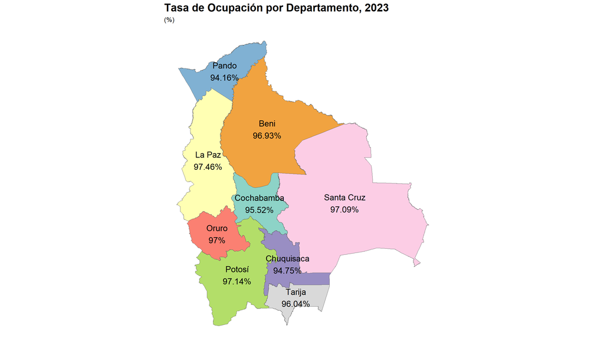

```r
#Archivo shapefile
##https://gadm.org/download_country.html
Dat_Map <- read_sf("~/Git_Portafolio/Portafolio/Inidcadores Laborales/Datos/Datos de Bolivia map/gadm41_BOL_1.shp")

Tas_O_Dep <- ECE_23 %>%
  filter(!is.na(condact)) %>%
  mutate_at(vars(depto, condact), as_label) %>%
  group_by(depto, condact) %>%
  tally() %>%
  pivot_wider(names_from = condact, values_from = n) %>%
  mutate(Desempleo=sum(c(Cesante,Aspirante), na.rm=T)) %>%
  select(depto,Desempleo, Ocupado) %>%
  adorn_totals(where = "col") %>%
  adorn_percentages(denominator = "row") %>%
  as_tibble()

#Merge
Dat_Map%>%
  merge(Tas_O_Dep[,-4],by.x="NAME_1", by.y="depto", all=TRUE) %>%
  #Crear un punto Medio "centroides"
  mutate(centroid = map(geometry, st_centroid),
         coords = map(centroid, st_coordinates), #Coord.Punto medio
         coords_x = map_dbl(coords, 1),
         coords_y = map_dbl(coords, 2),
         label_pe=paste0(NAME_1,"\n",round(Ocupado*100,2),"%")) %>%
  ggplot(aes(fill=NAME_1)) +
  geom_sf(show.legend = F)+
  geom_text(mapping = aes(coords_x, coords_y, label = label_pe),size=14, size.unit = "pt",)+
  scale_fill_manual(values = new_colors)+
  theme_classic()+
  labs(title = "Tasa de Ocupación por Departamento, 2023", subtitle = "(%)")+
  theme(
    #Eliminamos los detalles de los ejes
    axis.title = element_blank(),
    axis.ticks = element_blank(),
    axis.text = element_blank(),
    axis.line = element_blank(),
    plot.title = element_text(face="bold", size=18)
  )
```

# 5 Población Ocupada

## 5.1 Participación de la Población Ocupada Según Grupo Ocupacional

Las categorías de otras ramas de actividad se extraen del informe de la encuesta continua de empleo, 2023.

Está compuesta por: Servicio de organismos extraterritoriales; explotación de minas y canteras; suministro de electricidad, gas, vapor y aire acondicionado; suministro de agua, evac. de aguas residuales, gestión de desechos; informaciones y comunicaciones; intermediación financiera y seguros; actividades inmobiliarias; servicios profesionales y técnicos; actividades de servicios administrativos y de apoyo; servicios de salud y asistencia social; actividades artísticas, de entretenimiento y recreativas; otras actividades de servicios; actividades de hogares privados; servicio de organismos extraterritoriales.

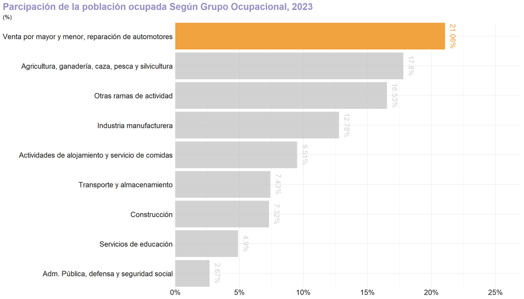

```r
#Manejo de Texto
text <- c("Servicio de Organismos Extraterritoriales; Explotación de minas y canteras; Suministro de electricidad, gas, vapor y
aire acondicionado; Suministro de agua, evac. de aguas residuales, gestión de desechos; Informaciones y comunicaciones; Intermediación financiera y
seguros; Actividades inmobiliarias; Servicios profesionales y técnicos; Actividades de servicios administrativos y de apoyo; Servicios de salud y asistencia social;
Actividades artísticas, entretenimiento y recreativas; Otras actividades de servicios; Actividades de hogares privados; Servicio de organismos extraterritoriales.")

Categ <- text %>%str_split(pattern = ";") %>% #Dividimos el texto
  unlist() %>% #Transformar Lista a vector
  as_tibble() %>%
  rename("Categoría"=value) %>%
  mutate(Categoría=str_to_sentence(trimws(ifelse(
    str_detect(Categoría, "\n"),
    gsub("\n", "",Categoría), Categoría))))#Convertir a titulo y eliminar espacios

#Gráfico
ECE_23 %>%
  filter(!is.na(condact)) %>%
  mutate(caeb_op=str_to_sentence(trimws(as_label(caeb_op))),
         condact=as_label(condact),
         Act_Eco=case_when(
           caeb_op %in% Categ$Categoría~"Otras ramas de actividad",
           is.na(caeb_op)~NA,
           TRUE~caeb_op)) %>%
  group_by(Act_Eco, condact) %>%
  tally() %>%
  filter(condact=="Ocupado") %>%
  adorn_percentages(denominator = "col") %>%
  ggplot(aes(x=fct_reorder(Act_Eco, n, .desc = F), y=n))+#Ordenamos los valores fct
  geom_bar(stat = "identity", fill= "#f1a340")+
  scale_y_continuous(limits = c(0,0.27), n.breaks = 5, labels =scales::percent)+
  coord_flip(expand = F)+
  labs(title = "Parcipación de la población ocupada Según Grupo Ocupacional, 2023", subtitle = "(%)", x=NULL, y=NULL)+
  geom_text(aes(label=paste0(round(n*100, 2),"%")), vjust=-1, color="#f1a340",size=14, size.unit = "pt", angle=270)+
  gghighlight(Act_Eco== "Venta por mayor y menor, reparación de automotores", use_direct_label = F)+
  theme_minimal() +
  theme(
    legend.position = 'top',
    legend.justification = "left",
    legend.location = "plot",
    plot.title = element_text(color="#998ec3", face="bold", size=18),
    plot.title.position = "plot",
    axis.text.x = element_text( color="gray12",size=14),
    axis.text.y = element_text( color="gray12",size=14),
    axis.title = element_blank(),
    legend.title =element_blank(),
    legend.text =element_text(size=14))
```

## 5.2 Cambio en la Participación de la Población Ocupada, Según Grupo Ocupacional en el Año

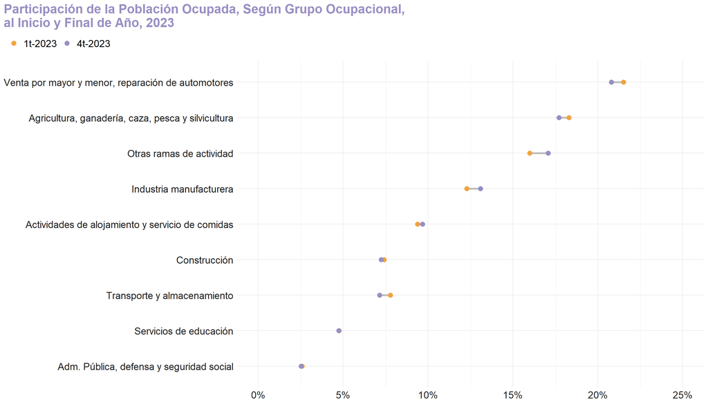

```r
ECE_23 %>%
  mutate(trim=as_label(trim),
         caeb_op=str_to_sentence(trimws(as_label(caeb_op))),
         condact=as_label(condact),
         Act_Eco=case_when(
           caeb_op %in% Categ$Categoría~"Otras ramas de actividad",
           is.na(caeb_op)~NA,
           TRUE~caeb_op)) %>%
  group_by(trim, condact,Act_Eco) %>%
  tally() %>%
  filter(condact=="Ocupado") %>%
  pivot_wider(names_from = trim, values_from = n) %>%
  adorn_percentages(denominator = "col") %>%
  ggplot()+
  geom_segment(aes(x=reorder(Act_Eco,`4t-2023`),
                   xend=Act_Eco, y=`1t-2023`, yend=`4t-2023`),
               color="grey", size=1.3)+
  geom_point(aes(x=Act_Eco,y=`1t-2023`, color="1t-2023"),size=3)+
  geom_point(aes(x=Act_Eco,y=`4t-2023`,color="4t-2023"), size=3)+
  scale_y_continuous(limits = c(0,.25),  n.breaks = 5, labels =scales::percent )+
  coord_flip()+
  scale_color_manual(values = c(`1t-2023` = "#f1a340",
                                `4t-2023`= "#998ec3"))+
  labs(color="Trimestre",x="",y="Participación", title = "Participación de la Población Ocupada, Según Grupo Ocupacional,\nal Inicio y Final de Año, 2023")+
  theme_minimal() +
  theme(
    legend.position = 'top',
    legend.justification = "left",
    legend.location = "plot",
    plot.title = element_text(color="#998ec3", face="bold", size=18),
    plot.title.position = "plot",
    plot.subtitle = element_text(color="gray12"),
    axis.text.x = element_text( color="gray12",size=14),
    axis.text.y = element_text( color="gray12",size=14),
    axis.title = element_blank(),
    legend.title =element_blank(),
    legend.text =element_text(size=14))
```

## 5.3 Distribución de la Población Ocupada, Según Etnicidad y Grupo Ocupacional

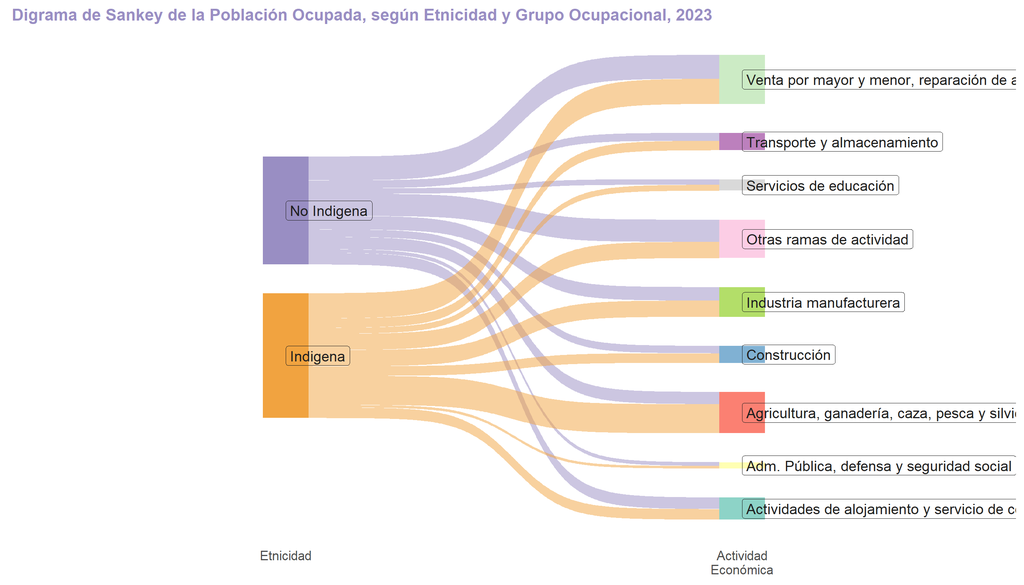

```r
#Data
Dta_sank <- ECE_23 %>%
  filter(condact==1) %>% #Ocupados
  mutate(caeb_op=str_to_sentence(trimws(as_label(caeb_op))),
         Etnic=case_when(
           s1_17==1~"Indigena",
           s1_17==2~"No Indigena",
           TRUE~NA),
         Act_Eco=case_when(
           caeb_op %in% Categ$Categoría~"Otras ramas de actividad",
           is.na(caeb_op)~NA,
           TRUE~caeb_op)) %>% select(Act_Eco,Etnic)%>%
  na.omit() %>%
  make_long(Etnic,Act_Eco)

#Gráfico de sankey

##Plot
Dta_sank %>%
  ggplot(aes(x = x
              , next_x = next_x
              , node = node
              , next_node = next_node
              , fill = factor(node),
              label=node))+
  geom_sankey(flow.alpha = 0.5, show.legend = F)+
  geom_sankey_label( colour="gray12",fill=NA,
                    hjust = "left", size=5)+
  scale_x_discrete(labels=c("Etnicidad", "Actividad\nEconómica"))+
  labs(title="Digrama de Sankey de la Población Ocupada, según Etnicidad y Grupo Ocupacional, 2023", x=NULL)+
   scale_fill_manual(values = new_colors)+
  theme_sankey(base_size = 16) +
  theme(
    legend.position = "none",
    plot.title = element_text(color = "#998ec3", face="bold", size=16))
```

# 6 Conclusión